# Midterm - solutions

Modern Research Methods

This exam is due **Friday, March 6th at 5pm**. Please turn your .html AND .Rmd files into Canvas. Your .Rmd file should knit without an error before turning in the exam. Your .html file should also be formatted appropriately. Be sure to look at your knitted html before you submit it.

You may use class materials (slide, notes, and readings) and the internet as resources to complete your exam. **However, you must complete the exam on your own**. You should not discuss the exam with anyone other than Professor Lewis or Jaeah.

1. What does the term “cumulative science” mean? Your response should make reference to examples we’ve discussed in class and the course readings. [1-2 paragraphs]

> Cumulative science is the sharing of data and findings that build upon each other in hopes of making greater strides in different fields, particularly pyschology. By sharing data, it allows for greater collaboration across many different disciplines and between researchers all over the world. Additionally this method can help reduce setup time of an experiment if all the details of past experiment are available to the public, specifically through version control. This is examined in depth in the article: “Excuse Me, Do You Have a Moment to Talk About Version Control?”. Jennifer Bryan explains the importance of using Git and Github for statistical and data scientific workflows. Some of the reasons she cites it is beneficial to use Git are that it allows for more structured collaboration and using common mechanics across work modes helps eliminate the process relearning. Another article that talks about open source collaboration as a way of facilitating the cumulative nature of science is “Scientific Utopia: I. Opening Scientific Communication” Nosek states “Because science is cumulative, researchers working on similar problems would benefit from learning about each other’s results as soon as possible.” Here, Nosek directly addresses how science advances by building on previous advancements, and how this process can be accelerated through increased scientific communication. - Themi Bournias

> Cumulative science refers to the perspective of viewing scientific progress as cumulative; i.e, new scientific knowledge is built upon on the findings in previous research and each other’s research. One example is the Suspicious-Coincidence Effect. At first, Xu and Tenenbaum (2007) found that adult and children learners’ learning curves for new words follow a rational statistical principle. When the examples given for a word to be learned cluster within a taxonomy, they detect this “suspicious coincidence” and infer the mapping between the novel label and the level of taxonomy shown. However, built upon Xu and Tenenbaum’s work, another group of researchers presented evidence showing that such “suspicious coincidence” only appeared when the exemplars are shown simultaneously (Spencer et al., 2011). When the stimuli are presented sequentially, the participants do not show the same generalization patterns. But then later on in Lewis & Frank (2018) they built upon the seemingly contradicting findings in Xu and Tenenbaum (2007) and Spencer et l. (2011), showing that the contradiction is due to the oversight of an additional factor: the trial order. This series of study is an example of cumulative science: each study is built upon on the previous work; and by integrating the insights from the previous works, deeper, more refined understanding of word learning (specifically suspicious-coincidence effect) has been gained. - Anjie Cao
1. **[a]** Define the terms “reliability” and “validity.”  
   **[b]** Assess the validity of Zettersten and Lupyan (2020), Exp. 1A.  
   **[c]** Describe how you would assess the reliability of Zettersten and Lupyan (2020), Exp. 1A.

**[a]**

> Reliability is the consistency of a measurement, meaning how much of the time a variable will be reported as the same given multiple measurements of an identical input. There are several subtypes of validity, but in general it refers to how well a measurement actually captures the construct it supposedly measures. For example, how often a person smiles has low validity as a measurement of happiness, because there are many reasons why people smile other than genuine happiness. -Isobel Stephen

**[b]**

> The experiment set out to test if having a name for something made it easier to categorize. This is somewhat valid for experiment 1A as it was testing easily-named colors vs difficult-to-name colors, but I would say that it doesn’t really extend beyond the scope of color categorization. It does a great job as testing the effects of high-nameability vs. low-nameability on the categorization of color. - Zoe Marshall

**[c]** I would assess it by running the experiment again. “Test-retest reliabilty” = running the experiment again with the same subjects and comparing subjects individual performance on trial1 vs. trial2.

2. Suppose you were interested in estimating how many words a child knows (their vocabulary size). Describe three different variables that you could measure to estimate the size of a child’s vocabulary size (each variable should be of a different type). For each variable, give a one sentence description of the variable, the variable type, *and* one example value of that variable with units.

> One qualitative variable that could be used to estimate how many words a child knows would be how sure they are of the meaning of the word with values ranging from “unsure”, “moderately sure”, and “very sure”; for instance, if asked about how sure they are about the definition of a word, the child could respond by saying that they were “very sure” about their response. - Sarah Chen

> Time to list 100 words. (Real Number) 300.21 Seconds.- Funglun Chan

> Quantitative variable, Integer: CDI-Score. Calculate the child’s score on the Mac-Arthur Bates Communicative Development Inventories. Example: 58, 63…. - Anjie Cao

> To estimate the size of a child’s vocabulary you could have the variable of the child’s age (continuous), level of parent education (categorical), and number of hours books in the house (discrete). The child’s age could be measured continuously starting with birth as the meaningful zero point, so a child could be 7.25 years old. The Level of parent education could be coded with ordinal levels such as some high school, high school diploma, undergraduate degree, graduate degree. The number of books in the house is a discrete variable and I think it is useful because other studies have shown that children that are read to more often perform better on language tests later on. An example of a value of this variable could be 33 books. - Nicole Casey
1. Use Google Sheets to look at [this dataset](https://docs.google.com/spreadsheets/d/1jlvmGX0wz6ege9W0ADN73SgMD9gURSg0lQ7Z5Nw3sMQ/edit?usp=sharing).  
   **[a]** List 5 things about the data in Table 1 that are not tidy.  
   **[b]** What are the observations in this dataset?  
   If it’s helpful, you can learn more about this dataset [here](https://www.un.org/en/development/desa/population/migration/data/estimates2/docs/MigrationStockDocumentation_2019.pdf)

**[a]**

> Five things that are not tidy in Table 1 are: 1. Year (a general variable) is not its own column; instead, each specific year has a column 2. The international migrant stock at mid-year by sex is a large merged cell acting as a “title” rather than having a column for the numerical variable “international migrant stock at mid-year” and another column for the variable “Sex of international migrant stock” (Male, Female, Both sexes) 3. Geographic regions (such as “Southern Africa”) for countries are included in the same column as the country names themselves, when there could be a separate column for geographic region (Benin…..Western Africa, Botswana….Southern Africa, etc.) 4. The values for migrant count in each major area, region, country, or area of destination are all in the same row - labeled by country - rather than each having a distinct row for each observation (One row for international migrant count of females in Nigeria in 1990, one row for international migrant count of males in Nigeria in 1990, one row for international migrant count of both sexes in Nigeria in 1990, one row for international migrant count of females in Nigeria in 1995, one row for international migrant count of males in Nigeria in 1995, etc.) 5. “Summary” data that are larger observations (Migrant counts of people by income group or by UN development groups, rather than by country) are included in the same table when they should be placed into separate tables (Table 1: International migrant stock at mid-year by income group, Table 2: International migrant stock at mid-year by UN development group, Table 3: International migrant stock at mid-year by geographic region, Table 4: International migrant stock at mid-year by country) - Victoria Shiau

**[b]**

> Observations are the population of international migrant stock of a certain location, sex, year. - Funglun Chan

> An observation is the immigrant stock in a given year, for a given gender, in a given country/country group - Yinxuan Fu
1. Go to the [dataisugly subreddit](https://www.reddit.com/r/dataisugly/) and find one plot that you think is a particularly severe offender of the plotting guidelines we discussed in class.  
   **[a]** Provide a link to that plot.  
   **[b]** Describe what you take to be the main message of the plot.  
   **[c]** Describe 5 things you would change in the plot to make it better at conveying this message.  
   **[d]** Imagine you were going to recreate and/or improve upon this plot using `ggplot`. List the name of one geom function you would use to make your plot (e.g. `geom_boxplot`).

> a: https://www.reddit.com/r/dataisugly/comments/fbxfq5/i_dont_want_to_live_longer_anymore/ b:That human life expentancy has increased over the years. c: 1 I would change the plot to be a bar graph, with years on the x axis and life expectancy on the y axis. 2 I would change the axes to have a more precise/accurate scale 3 I would make each year a different color 4 I might include other variables such as continent or region 5 Change the title to just “Average Life Expectancy” d:geom_bar()- Themi Bournias

> [a]. https://external-preview.redd.it/AdAxCvCVoLhHQ9idpr4dQY78cjKiojvnnyBmXCr78TM.jpg?auto=webp&s=61a5aab24a4e24b7a193b1af3ce50c2f116128b1 [b]. Main message: Men and women have similar distributions in terms of how long they can survive “naked in the wild”. [c]. Change the plot: 1. Change from 3D to 2D 2. Flip the axes: have the days being plotted on the x-axis. 3. Make a density plot or histogram with some transparency on the color for better comparison 4. Add legends for the color (maybe use less stereotyped colors and show some acknowledgment for the lack of data for non-binary people?) 5. Have a more informative title: unclear what the current title and subtitle means. [d]. geom_density - Anjie Cao

> Link: https://www.reddit.com/r/dataisugly/comments/fe3tkb/let_me_plot_a_bunch_of_uncomparable_variables/ The main message of the plot is overall change over time data trends in American Public Schooling. According to the person who made the plot, this means the total cost of schooling, number of employees, enrollment, reading scores, math scores, and science scores. I would seperate the data into several plots, namely, the total cost of schooling plot, the number of employees vs enrollment numbers, and the scores trends. I would only use color coding on the separate scores plot, and possibly on the people numbers plot (employees and enrollment). I would change the y axes of all of the new plots to a continuous scaled number, not percentages. I would take away the background, the lines aren’t adding anything to the understand and the grey distracts because it is heavy. I would change the descriptions on the right to include descriptions of exactly what the plot is showing/aiming to show, right now it is just one variable’s description, and it’s not clear how it has to do with percentages. To remake this plot, I would use geom_line. - Maya Greenholt

> a: https://www.reddit.com/r/dataisugly/comments/fe3tkb/let_me_plot_a_bunch_of_uncomparable_variables/ b: The main message of this plot I believe is to display the change of cost for kindergarten to 12th grade education from 1970 to 2010. However, there are a lot of other irrelevant information about other general trends public schools have had from 1970 to 2010. c: 1. If the graphic was supposed to display increased costs: get rid of all variables except ‘total cost’ 2. If the graphic was support to show public school trends: pick one specific trend instead of putting all the variables into one confusing graph (for example, pick to compare how scores in reading, math, and science have changed from 1970 to 2010) 3. The y-axis should be according to the relevant y-axis after picking a specific trend (i.e. either $ value for costs, or score/points for the academic tests) 4. Get rid of the dotted line parts for ‘total cost’ since it is supposed to be solid 5. Graphic’s aesthetics are off; there should be no shadows or uneccessary ink used d: I would use geom_line() to recreate this graph. - Nicole Hsing
1. Rhoda is a researcher in the psychology department at CMU. She has the hypothesis that children will be more likely to show the mutual exclusivity effect in word learning if the child is asked to find the novel object in infant directed speech, compared to adult directed speech. Rhoda runs a study testing this hypothesis with a sample of children from the local nursery school.  
   **[a]** Explain what it would mean to reproduce this study.  
   **[b]** Explain what it would mean to replicate this study.

> a: To reproduce this study would be to get the same results as Rhoda while using the same data set. This would be done by an outside researcher, who would use the same raw data and the same statistical analysis and get the same results. b: To replicate this study would be to repeat the entire experiment, use the same analysis plan, and get the same data pattern as Rhoda. - Themi Bournias

> a: To reproduce this study, we would take Rhoda’s data and follow her process for data analysis to see if we get the same statistical results as her; b: To replicate this study, we would follow Rhoda’s whole experimental process in which we use the same population (children from nursery school), test the same hypothesis, follow the same experimental design and analysis plan, and then see if we get the same result. - Shruti Murali
1. Jasmina conducts a replication of an experiment. She uses her data to calculate (i) a p-value, (ii) confidence intervals, and (iii) an effect size. The paper describing the original experiment also reports a p-value, confidence intervals, and an effect size. Explain what each of these three statistical tools will tell Jasmina about the relationship between the original experiment and her replication.

> p-value: p-value refers to the probability of getting two sample means that are at least as different as the difference we found if the null hypothesis is true. If the p-values in the replication and the original experiment are close to each other and are both small, then it suggests that the replication is successful; Confidence intervals: Confidence intervals refer to a range of plausible values. For example, for a 95% intervals, if we run the experiment over and over again by drawing samples from the same populations and calculate the time we run the experiment, then 95% of the intervals would contain the true mean for the population. In Jasmina’s case, we should expect to see overlapping confidence intervals between the original experiment and the replication if the replication is successful. Effect size: Effect size is a standardized way to measure the difference between performance in two conditions and taking into account the dispersion of the two conditions. Larger dispersion will lead to smaller effect size and smaller dispersion will lead to larger effect size. In Jasmina’s case, for successful replication, we should also expect to see a similar effect size if the replication has a similar sample size with the original. - Anjie Cao
1. The mean IQ of *all the people* on the island Lorbia is 135 (they’re very good at taking IQ tests!). You take a sample of 10 people from Lorbia and calculate the mean IQ and a 95% confidence interval around the mean. You repeat this procedure for a total of 200 samples. How many of your 200 confidence intervals will include the value 135?

> .95 * 200 = 190

> 190 confidence intervals will contain the true mean. - Jailyn Zabala
1. This question uses the data from the Many Babies project from Assignment 5.  
   **[a]** Calculate effect sizes for the replications in two of the labs. Specifically, calculate an effect size for the replication experiment conducted by the “babylabnijmegen” lab and an effect size for the replication experiment conducted by the “infantllmadison” lab.  
   **[b]** Plot the two effect sizes.  
   **[c]** Which lab had the largest effect size? State the point estimate and confidence interval for the effect size for that lab.  
   **[d]** Interpret the effect sizes. Explain what it means to have a large effect size in this experiment. Would you guess that these two effect sizes are statistically different from each other? Why or why not?  
   **[e]** Imagine we ran another replication of this experiment and got a *negative* effect size. What would this mean?

**[a]**

```r
many_babies_data <- read_csv("data/many_babies_data.csv")

many_babies_data_summary <- many_babies_data %>%
  group_by(lab, condition) %>%
  summarize(mean_prop_right = mean(mean_looking_time),
            sd = sd(mean_looking_time),
            n = n())
```

```r
babylabnijmegen_effect_size <-
  mes(many_babies_data_summary %>% filter(lab == "babylabnijmegen", condition == "IDS") %>% pull(mean_prop_right), # m.1
    many_babies_data_summary %>% filter(lab == "babylabnijmegen", condition == "ADS") %>% pull(mean_prop_right),# m.2
    many_babies_data_summary %>% filter(lab == "babylabnijmegen", condition == "IDS") %>% pull(sd), #sd.1
    many_babies_data_summary %>% filter(lab == "babylabnijmegen", condition == "ADS") %>% pull(sd), #sd.2
    many_babies_data_summary %>% filter(lab == "babylabnijmegen", condition == "IDS") %>% pull(n), #n.1
    many_babies_data_summary %>% filter(lab == "babylabnijmegen", condition == "ADS") %>% pull(n), #n.2
    verbose = F)  %>%
  mutate(lab= "babylabnijmegen")
```

```r
infantllmadison_effect_size <-
  mes(many_babies_data_summary %>% filter(lab == "infantllmadison", condition == "IDS") %>% pull(mean_prop_right), # m.1
    many_babies_data_summary %>% filter(lab == "infantllmadison", condition == "ADS") %>% pull(mean_prop_right),# m.2
    many_babies_data_summary %>% filter(lab == "infantllmadison", condition == "IDS") %>% pull(sd), #sd.1
    many_babies_data_summary %>% filter(lab == "infantllmadison", condition == "ADS") %>% pull(sd), #sd.2
    many_babies_data_summary %>% filter(lab == "infantllmadison", condition == "IDS") %>% pull(n), #n.1
    many_babies_data_summary %>% filter(lab == "infantllmadison", condition == "ADS") %>% pull(n), #n.2
    verbose = F)  %>%
  mutate(lab = "infantllmadison")
```

```r
both_es <- bind_rows(infantllmadison_effect_size, babylabnijmegen_effect_size)

tidy_es <- both_es %>%
  select(lab, d, l.d, u.d) %>%
  rename(ci_lower = l.d,
         ci_upper = u.d)

kable(tidy_es)
```

| lab | d | ci_lower | ci_upper |
| --- | --- | --- | --- |
| infantllmadison | 0.63 | 0.32 | 0.94 |
| babylabnijmegen | 0.25 | -0.13 | 0.63 |

**[b]**

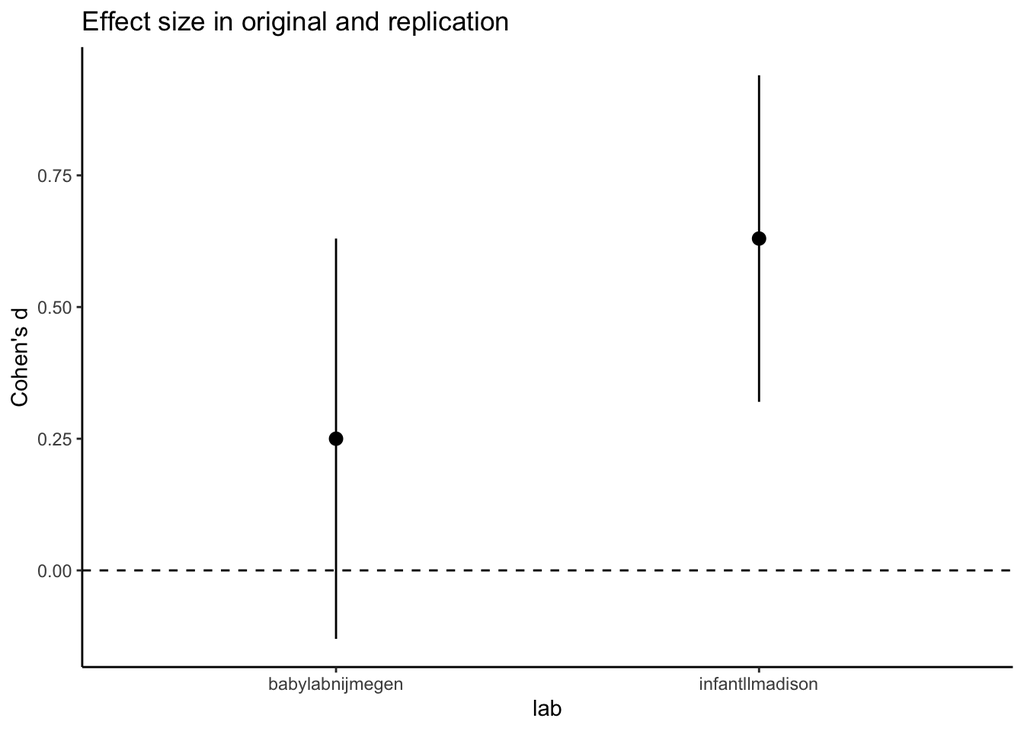

```r
ggplot(tidy_es, aes(y = d, x= lab)) +
  geom_pointrange(aes(ymin = ci_lower, ymax = ci_upper)) +
  ggtitle("Effect size in original and replication") +
  geom_hline(aes(yintercept = 0), linetype = 2) +
  ylab("Cohen's d") +
  theme_classic()
```

**[c]**  
infantllmadison had a larger effect size. The point estimate for effect size for that lab is 0.63, with a confidence interval of 0.32 to 0.94. The way this is conventionally reported in text is Cohen’s d is .63 [95% CI: .32, .94]. Note that there are no units!

**[d]**  
A larger effect size in this experiment means that the difference in looking time between Adult Directed Speech (ADS) and Infant Directed Speech (IDS) is longer. I.e., using infants look longer at the screen when infant directed speech is playing, relative using adult directed speech. We would interpret this to mean that infants have a STRONGER preference for IDS relative to ADS.  
The set of “plausible values” for the means in the two conditions is very similiar (i.e. overlapping). Thus, it is unlikely that these two means are statistically different from each other.

**[e]**  
If we got a negative effect size, this would mean that the mean looking time was longer for adult directed speech than with infant directed speech (direction of difference is flipped).  
Cohen’s d = `(mean1 - mean2)/standard_deviation`  
You can choose whether an effect is positive or negative based on how you define mean1 and mean2. In general, you want to define which is mean1 and which is mean2 so that you get a postive effect size if your hypothesis is correct. In this case, the hypothesis is “Infants prefer infant directed speech”. So we’d want to define mean1 to be mean looking time in the IDS condition and mean2 to to be mean looking time in the adult directed speech condition. Defined this way, we will get a postive value when mean1 > mean2 (i.e. when infants look longer at IDS relative to ADS).

1. How are the functions `filter` and `distinct` similar? How are they different? Use data from the Many Babies project to demonstrate your answer. Your answer should involve both code *and* a clear explanation.

`filter` and `distinct` are similar in that they both pull observations (rows) from your dataset. They are different in that while `filter` pulls all observations meeting a certain criteria that you give, `distinct` pulls one row per unique or “distinct” instance of the variable you give it. For example:

```r
many_babies_data %>%
  filter(lab== "babylabnijmegen")
```

```
## # A tibble: 110 x 5
##    lab             subid   age_days condition mean_looking_time
##    <chr>           <chr>      <dbl> <chr>                 <dbl>
##  1 babylabnijmegen ba0169       245 ADS                    8.38
##  2 babylabnijmegen ba0169       245 IDS                    7.28
##  3 babylabnijmegen ba01912      323 ADS                    5.28
##  4 babylabnijmegen ba01912      323 IDS                    5.21
##  5 babylabnijmegen ba0269       206 ADS                    5.20
##  6 babylabnijmegen ba0269       206 IDS                    9.33
##  7 babylabnijmegen ba02912      335 ADS                    9.32
##  8 babylabnijmegen ba02912      335 IDS                    9.43
##  9 babylabnijmegen ba0369       257 ADS                    8.42
## 10 babylabnijmegen ba0369       257 IDS                    7.35
## # … with 100 more rows
```

```r
many_babies_data %>%
  distinct(lab)
```

```
## # A tibble: 6 x 1
##   lab
##   <chr>
## 1 babylabnijmegen
## 2 babylabparisdescartes1
## 3 babylabplymouth
## 4 babylabpotsdam
## 5 babylabprinceton
## 6 infantllmadison
```

The following questions concern the set of studies reported in “Gender stereotypes about intellectual ability emerge early and influence children’s interests” by Lian, Leslie, and Cimpian (2017). You can find additional information about the study methods in the Supplementary Materials. In addition, there is an [OSF repository](https://osf.io/jfm26/?view_only=9a8505d4e87b456a89f255b43e21234e) that contains the raw data from the studies reported in the paper. The repository includes a document explaining each of the variables. *In order to complete the questions about this dataset, you’ll need to read the paper/supplementary materials to understand the design of Study 1 and Study 2.*

1. Load the data from Study 1 into R. Sort the data so that children who have the highest value for `stereo` are at the top. Show the first 7 rows of this dataset.

```r
lian_data <- read_csv('data/_Study1.csv')
```

```r
lian_data %>%
  arrange(-stereo) %>%
  slice(1:7) %>%
  kable()
```

| subj | gender | age | trait | stereo |
| --- | --- | --- | --- | --- |
| 5 | 1 | 7 | 1 | 1 |
| 6 | 1 | 5 | 1 | 1 |
| 22 | 2 | 5 | 1 | 1 |
| 23 | 1 | 5 | 1 | 1 |
| 88 | 1 | 7 | 1 | 1 |
| 90 | 1 | 7 | 1 | 1 |
| 94 | 1 | 5 | 1 | 1 |

When you look at the data in Study 1 you might notice that the values for the variables `gender` and `trait` are numbers. Coding qualitative variables with numbers is not ideal since it’s not obvious what these number correspond to, and so it’s easy to make errors when you’re interpreting the data. The code below recodes the variables `gender` and `trait` so that the values are interpretatable strings, rather than numbers. Make sure to use the below code to fix the variables `gender` and `trait` in your data frame.

```r
lian_data_tidy <- lian_data %>%
  mutate(gender = as_factor(gender),
         gender = fct_recode(gender, "boy" = "1", "girl" = "2"),
         trait = as_factor(trait),
         trait = fct_recode(trait, "nice" = "0", "smart" = "1"))
```

1. How many children participated in the experiment in each age group?

```r
lian_data_tidy %>%
  distinct(subj, .keep_all = T) %>%
  count(age) %>%
  kable()
```

| age | n |
| --- | --- |
| 5 | 32 |
| 6 | 32 |
| 7 | 32 |

1. Calculate the standard error of the mean for the dependent variable (mean proportion of times children linked the target trait to their own gender) for girls on the “nice” trait task.

```r
lian_data_tidy %>%
  filter(gender == "girl", trait == "nice") %>%
  summarize(n = n(),
            sd = sd(stereo)) %>%
  mutate(sem = sd/sqrt(n)) %>%
  kable()
```

| n | sd | sem |
| --- | --- | --- |
| 48 | 0.2200663 | 0.0317638 |

1. Recreate Figure 1A and Figure 1B from the paper. Include error bars that are 95% confidence intervals (rather than standard errors).

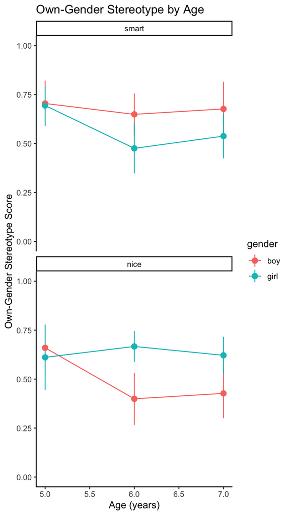

```r
plotting_data <- lian_data_tidy %>%
  mutate(trait = fct_rev(trait)) %>%
  group_by(trait, gender, age) %>%
  summarize(mean = mean(stereo),
            sd = sd(stereo),
            n = n()) %>%
  mutate(ci_range_95 =  qt(1 - (0.05 / 2), n - 1) * (sd/sqrt(n)),
         ci_lower = mean - ci_range_95,
         ci_upper = mean + ci_range_95)

ggplot(plotting_data, aes(x = age, y = mean, color = gender))  +
  geom_pointrange(aes(ymin = ci_lower, ymax = ci_upper)) +
  ylim(0,1) +
  facet_wrap(~trait, ncol = 1) +
  geom_line() +
  ylab("Own-Gender Stereotype Score") +
  xlab("Age (years)") +
  ggtitle("Own-Gender Stereotype by Age") +
  theme_classic()
```

1. Look at Figure 1 in the paper. Compare the error bars for the seven-year-old girls in panel B (Study 1) and panel D (Study 2). State one reason why they might be smaller in Study 2 compared to Study 1.

95% CI width = `~1.96 * SE`

SE = `sd/sqrt(n)`.

Larger sample size means smaller SE and therefore smaller CI (i.e. smaller range of plausible values for the mean).

1. **Extra credit**: Use the data from Study 1 to make a second plot. Make a violin plot (`geom_violin`) showing the distribution of the mean proportion of times children linked the target trait to their own gender. Show a separate violin for each unique combination of gender and trait. Add a point estimate and a confidence interval to each violin showing the corresponding 95% confidence interval.

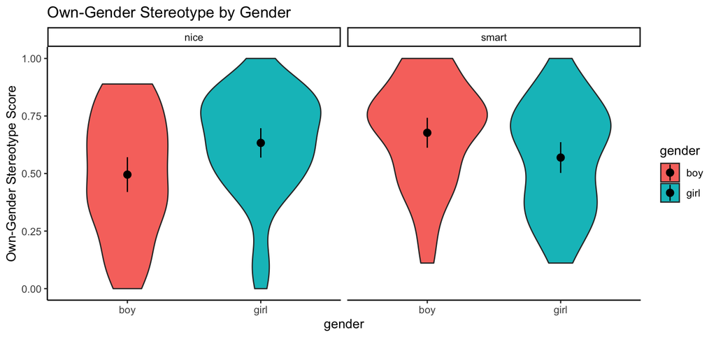

```r
plotting_data2 <- lian_data_tidy %>%
  group_by(trait, gender) %>%
  summarize(mean = mean(stereo),
            sd = sd(stereo),
            n = n()) %>%
  mutate(ci_range_95 =  qt(1 - (0.05 / 2), n - 1) * (sd/sqrt(n)),
         ci_lower = mean - ci_range_95,
         ci_upper = mean + ci_range_95)

ggplot(data = lian_data_tidy)  +
  geom_violin(data = lian_data_tidy, aes(x = gender, y = stereo, fill = gender)) +
  geom_pointrange(data = plotting_data2,
                  aes(x = gender, y = mean, fill = gender, ymin = ci_lower, ymax = ci_upper)) +
  ylim(0,1) +
  facet_wrap(~trait) +
  ylab("Own-Gender Stereotype Score") +
  ggtitle("Own-Gender Stereotype by Gender") +
  theme_classic()
```